# FERTILITY RATEs & CONTRACEPTIVE USE IN INDIA

Evelyn Viola

2023-22-12

# Introduction

India is one of the world’s most populated countries. As of the year 2021, India had a total population of 1.4 billion. Increased fertility rate is one of the contributing factors, and has been defined by United Nations (UN) ‘as the number of living children’ per woman [1].

This report presents an analysis of DHS data on reproduction. It will dive deep to show differences in number of children (fertility rate) across different geographic and socioeconomic levels in India.

# Demographic information

### Education

Different levels of education were analysed. As shown in the table below, majority of the women have secondary as their highest level of education, followed by women with do education.

| Education Level | Number of women |
| --- | --- |
| no education | 167304 |
| primary | 84983 |
| secondary | 370012 |
| higher | 101816 |

### Place of residency

Majority of the women, almost 75% live in rural area as shown in figure 1 below.

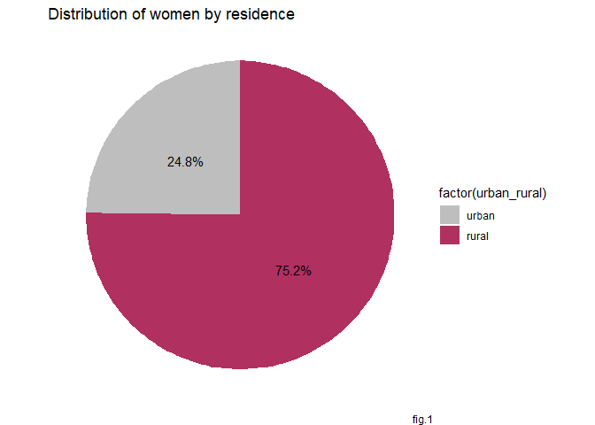

# Fertility rates across socioeconomic and demographic levels

### Based on Region

Below is a chart that shows distribution of number of children or fertility rates per region. In some regions like Uttar Pradesh the fertility rates rates are high compared to some regions like Chandigarh. Hoovering across the chart below gives a picture of each region in India.

[interactive chart not shown]

### Based on Education levels

Based on this analysis, fertility rate reduces with increase in education. As shown in the figure 3 below, the IQR, and even the median number of children is higher in those with no education and lower in those with higher education. This finding is similar to another study done in India which argued that education in women diffuses the process, whereby fertility differentials are the result of lags in the adoption of a new form of reproduction behavior [2].

### Based on Type of residence

As in figure 4 below, the number of children/fertility rate is higher in rural areas compared to urban areas. More analysis is ofcourse needed to determine the correlation between the two. But according to literature, due to a number of predisposing factors in urban areas, fertility rates tend to be lower [3].

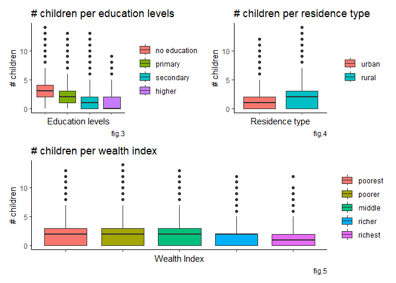

#### Wealth Index

Based on the analysis of this data, the richest women have less number of children (even the IQR in fig 5 shows), as compared to women who are poor or poorer.

# Knowledge and use of contraceptives

Based on the graph below, women do use contraceptives including the modern and traditional methods. Closer look at the relationship between contraceptive use shows that women who do not use any contraceptive method do not have children, and those who use the contraceptive methods do have children

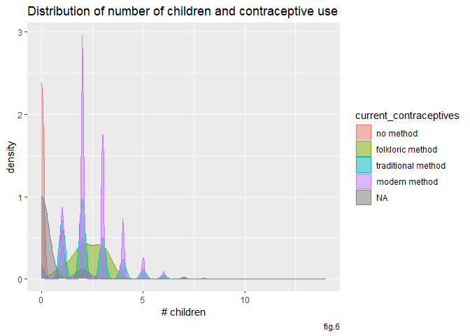

# References

1. United Nations (2019). Total fertility. Retrieved [here](https://www.un.org/esa/sustdev/natlinfo/indicators/methodology_sheets/demographics/total_fertility_rate.pdf)
2. Bhat, P. M. (2002). Returning a favor: Reciprocity between female education and fertility in India. *World development*, *30*(10), 1791-1803.
3. Brinker, G., & Amonker, R. (2013). Socioeconomic development and fertility trends among the states of India. *International Journal of Sociology and Social Policy*, *33*(3/4), 229-245.